# Validating primary care resource use and costs based on OMOP-mapped CPRD data against corresponding source data: the case of postmenopausal fragility fractures in the UK

Friday, 25 July 2025

# Overview

This report compares summary statistics for healthcare resource use (HCRU) and Costs between **SOURCE** and **OMOP** databases.

Results are stratified by:

- Population: **All patients** vs **Users only** (i.e., patients with at least one clinically relevant encounter)
- Encounter type: **All** vs **Clinically relevant only**
- Time frames: summaries are presented for the **overall follow-up period**, by **year**, and by **month** after index.
- Clinically relevant encounters were defined based on clinical expert judgment, using the specialty of the healthcare professional associated with each encounter record. The assessment was conducted separately for specialties recorded in CPRD Source and those mapped to OMOP.
- Unit costs were assigned using the latest (2024 edition) PSSRU Unit Costs of Health and Social Care manual. OMOP specialties were costed based on their corresponding SOURCE CPRD specialties.
- Where multiple SOURCE CPRD specialties mapped to the same OMOP concept ID, an average of their costs was used to assign a single unit cost in OMOP.
- For SOURCE CPRD specialties that did not map to an OMOP concept ID (i.e., no matching concept id), their costs were averaged and applied uniformly to all *Uncategorised* specialties in OMOP.

## Mapping specialties - plot test 1

The outer circle displays the SOURCE specialties, each linked to an OMOP specialty represented in the inner circle. SOURCE specialties are grouped and colored according to their associated OMOP specialty. Within each group, darker shades indicate specialties marked as clinically relevant. The length of each outer bar corresponds to the unit cost associated with that SOURCE specialty.

[ the figure needs some improvement and adjustments ]

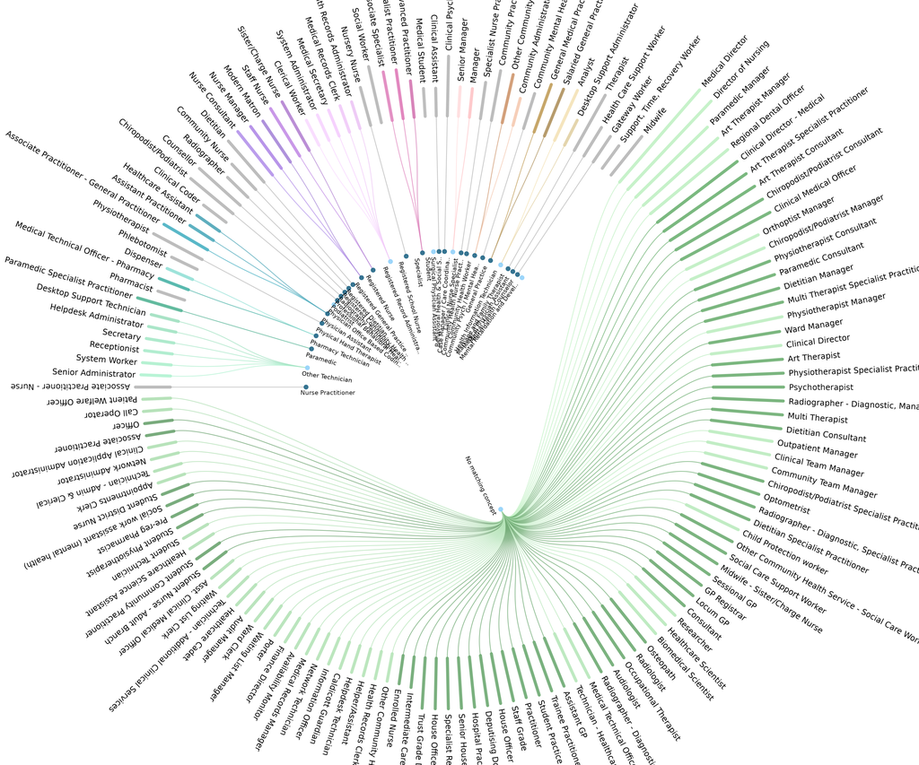

## Mapping specialties - plot test 2

This is another version of figure 1 and for the same purpose (once refined we can choose which one to use). It shows the mapping between OMOP specialties (first column) and their corresponding source specialties (second column), alongside a visual comparison of the unit costs used in the source and OMOP analyses. The goal is to highlight alignment or discrepancies between the two classifications in terms of both specialty definitions and associated costs.

[ the figure needs some improvement and adjustments ]

[figure not shown]

# Assumptions

Both CPRD_consultation and CPRD_observation tables are mapped to the OMOP visit_detail table, resulting in separate records even when they originate from the same clinical event (e.g., an observation recorded during a consultation appears as a distinct visit_detail record). Also, OMOP does not retain information about whether a visit record originated from a consultation or an observation.

Therefore, records without a provider, or with a provider lacking an assigned specialty, are excluded. We retain only one visit record per patient, per day, and per provider specialty (i.e., deduplication).

# Cohort

### Patients characteristics

We will combine the two tables into one like in old report (values have not changed, except users counts slightly)

##### Source

| Variable | N = 23,106 |
| --- | --- |
| Fracture Site | NA |
| Hip | 3,216 (14%) |
| Vertebra | 1,657 (7.2%) |
| NHNV | 18,233 (79%) |
| Censoring Event | NA |
| Max of 730 days from index date | 9,807 (42%) |
| End of Study | 6,094 (26%) |
| Fracture ensuing incident (index) fracture | 4,080 (18%) |
| End of data collection period | 1,526 (6.6%) |
| Death | 1,158 (5.0%) |
| Cancer | 375 (1.6%) |
| Paget’s disease of the bone, or other metabolic bone diseases | 55 (0.2%) |
| Max of 730 days from index date, End of Study | 7 (<0.1%) |
| Cancer, Fracture ensuing incident (index) fracture | 1 (<0.1%) |
| End of data collection period, Fracture ensuing incident (index) fracture | 1 (<0.1%) |
| Fracture ensuing incident (index) fracture, End of Study | 1 (<0.1%) |
| Max of 730 days from index date, Fracture ensuing incident (index) fracture | 1 (<0.1%) |
| Follow up time | 577 (191, 730) |
| Heathcare Service User Status | NA |
| Non-User | 640 (2.8%) |
| User | 22,466 (97%) |

##### OMOP

| Variable | N = 22,900 |
| --- | --- |
| Fracture fracture_site | NA |
| Hip | 3,197 (14%) |
| Vertebra | 1,699 (7.4%) |
| NHNV | 18,004 (79%) |
| Censoring Event | 0 (NA%) |
| Follow up time | 578 (192, 730) |
| Heathcare Service User Status | NA |
| Non-User | 682 (3.0%) |
| User | 22,218 (97%) |

### Specialties

[ we will combine the two tables into one ]

##### Source

Healthcare Provider Roles and Categories (Source-CPRD Summary)

| **Total Encounters** | **N = 901,535** |
| --- | --- |
| **Healthcare Provider Category** | NA |
| Administrative Non-clinical | 368,133 (40.8%) |
| General Practitioner | 361,781 (40.1%) |
| Nurse | 87,655 (9.7%) |
| Other | 83,966 (9.3%) |
| **Healthcare Provider Roles** | NA |
| General Medical Practitioner | 303,981 (33.7%) |
| Receptionist | 90,210 (10.0%) |
| Manager | 73,922 (8.2%) |
| System Administrator | 48,268 (5.4%) |
| Clerical Worker | 46,096 (5.1%) |
| Community Practitioner | 43,287 (4.8%) |
| Health Care Support Worker | 37,858 (4.2%) |
| Salaried General Practitioner | 26,363 (2.9%) |
| Healthcare Assistant | 25,945 (2.9%) |
| Community Administrator | 22,350 (2.5%) |
| Desktop Support Administrator | 21,074 (2.3%) |
| Senior Administrator | 16,046 (1.8%) |
| Community Nurse | 15,343 (1.7%) |
| Medical Secretary | 14,165 (1.6%) |
| Sessional GP | 12,341 (1.4%) |
| Secretary | 12,271 (1.4%) |
| Specialist Nurse Practitioner | 11,985 (1.3%) |
| GP Registrar | 11,921 (1.3%) |
| Staff Nurse | 7,071 (0.8%) |
| Phlebotomist | 6,052 (0.7%) |
| Pharmacist | 5,510 (0.6%) |
| Dispenser | 5,292 (0.6%) |
| Locum GP | 4,765 (0.5%) |
| Clinical Coder | 3,942 (0.4%) |

[output cut: 116 more lines]

##### OMOP

Healthcare Provider Roles and Categories (OMOP Summary)

| **Total Encounters** | **N = 877,293** |
| --- | --- |
| **Healthcare Provider Category** | NA |
| Administrative Non-clinical | 327,342 (37.3%) |
| General Practitioner | 325,922 (37.2%) |
| Other | 107,565 (12.3%) |
| Nurse | 85,458 (9.7%) |
| Uncategorised | 31,006 (3.5%) |
| **Healthcare Provider Roles** | NA |
| General Practice | 325,922 (37.2%) |
| Other Technician | 118,097 (13.5%) |
| Registered Record Administrator | 107,810 (12.3%) |
| Case Manager / Care Coordinator | 76,318 (8.7%) |
| Community Health Nurse Practitioner | 42,901 (4.9%) |
| Medical Physician Assistant | 36,677 (4.2%) |
| No matching concept | 31,006 (3.5%) |
| Physician Assistant | 28,368 (3.2%) |
| Community Health Worker | 22,347 (2.5%) |
| Health Information Technician | 20,920 (2.4%) |
| Registered Community Health Nurse | 15,197 (1.7%) |
| Clinical Nurse Specialist | 11,862 (1.4%) |
| Registered Nurse | 9,644 (1.1%) |
| Phlebotomist | 6,136 (0.7%) |
| Pharmacy Technician | 6,094 (0.7%) |
| Pharmacist | 5,488 (0.6%) |
| Physician Office Based Coding Specialist | 3,961 (0.5%) |
| Registered General Practice Nurse | 3,848 (0.4%) |
| Nurse Practitioner | 1,916 (0.2%) |
| Specialist | 593 (0.1%) |
| Surgical Physician Assistant | 543 (0.1%) |
| Physical Hand Therapist | 468 (0.1%) |
| Paramedic | 426 (0.0%) |
| Student | 236 (0.0%) |
| Professional Behavioral Health Counselor | 141 (0.0%) |
| Podiatrist | 112 (0.0%) |
| Community Psych / Mental Health Nurse | 90 (0.0%) |
| Registered Dietitian | 75 (0.0%) |
| Marriage and Family Therapist | 51 (0.0%) |
| Radiography Technologist | 28 (0.0%) |
| Behavioral Health & Social Service Providers, Psychologist, Clinical | 8 (0.0%) |
| Social Worker | 7 (0.0%) |
| Midwife | 3 (0.0%) |

# HCRU

### Overall

#### All Patients

##### All Encounters

###### **Observed**

| Cohort | mean | min | max | sd | median | lower_q | upper_q | se | ci_lower | ci_upper |
| --- | --- | --- | --- | --- | --- | --- | --- | --- | --- | --- |
| SOURCE | 39.02 | 1 | 678 | 37.39 | 28 | 14 | 51 | 0.25 | 38.54 | 39.5 |
| OMOP | 38.31 | 1 | 678 | 36.59 | 28 | 14 | 51 | 0.24 | 37.84 | 38.79 |

###### **Bootstrap** (with confidence intervals derived using normal, basic, and percentile methods).

| Cohort | mean | variance | sd | se | ci_norm_lower | ci_norm_upper | ci_basic_lower | ci_basic_upper | ci_perc_lower | ci_perc_upper |
| --- | --- | --- | --- | --- | --- | --- | --- | --- | --- | --- |
| SOURCE | 39.004 | 0.06 | 0.245 | 0.008 | 38.558 | 39.518 | 38.546 | 39.513 | 38.529 | 39.496 |
| OMOP | 38.317 | 0.061 | 0.247 | 0.008 | 37.827 | 38.796 | 37.802 | 38.782 | 37.846 | 38.827 |

##### Clinically Relevant Encounters

###### **Observed**

| Cohort | mean | min | max | sd | median | lower_q | upper_q | se | ci_lower | ci_upper |
| --- | --- | --- | --- | --- | --- | --- | --- | --- | --- | --- |
| SOURCE | 23.05 | 0 | 401 | 24.01 | 16 | 7 | 31 | 0.16 | 22.74 | 23.36 |
| OMOP | 22.66 | 0 | 444 | 24.08 | 16 | 7 | 30 | 0.16 | 22.35 | 22.97 |

###### **Bootstrap** (with confidence intervals derived using normal, basic, and percentile methods).

| Cohort | mean | variance | sd | se | ci_norm_lower | ci_norm_upper | ci_basic_lower | ci_basic_upper | ci_perc_lower | ci_perc_upper |
| --- | --- | --- | --- | --- | --- | --- | --- | --- | --- | --- |
| SOURCE | 23.049 | 0.023 | 0.152 | 0.005 | 22.753 | 23.351 | 22.752 | 23.349 | 22.752 | 23.349 |
| OMOP | 22.659 | 0.026 | 0.163 | 0.005 | 22.345 | 22.982 | 22.331 | 22.971 | 22.352 | 22.991 |

#### Users Only

##### All Encounters

###### **Observed**

| Cohort | mean | min | max | sd | median | lower_q | upper_q | se | ci_lower | ci_upper |
| --- | --- | --- | --- | --- | --- | --- | --- | --- | --- | --- |
| SOURCE | 40.01 | 1 | 678 | 37.44 | 29 | 15 | 52 | 0.25 | 39.52 | 40.5 |
| OMOP | 39.36 | 1 | 678 | 36.64 | 29 | 15 | 52 | 0.25 | 38.88 | 39.85 |

###### **Bootstrap** (with confidence intervals derived using normal, basic, and percentile methods).

| Cohort | mean | variance | sd | se | ci_norm_lower | ci_norm_upper | ci_basic_lower | ci_basic_upper | ci_perc_lower | ci_perc_upper |
| --- | --- | --- | --- | --- | --- | --- | --- | --- | --- | --- |
| SOURCE | 40.011 | 0.06 | 0.246 | 0.008 | 39.535 | 40.499 | 39.521 | 40.576 | 39.452 | 40.506 |
| OMOP | 39.36 | 0.057 | 0.24 | 0.008 | 38.897 | 39.837 | 38.874 | 39.822 | 38.906 | 39.854 |

##### Clinically Relevant Encounters

###### **Observed**

| Cohort | mean | min | max | sd | median | lower_q | upper_q | se | ci_lower | ci_upper |
| --- | --- | --- | --- | --- | --- | --- | --- | --- | --- | --- |
| SOURCE | 23.71 | 1 | 401 | 24.02 | 17 | 8 | 32 | 0.16 | 23.39 | 24.02 |
| OMOP | 23.36 | 1 | 444 | 24.12 | 16 | 7 | 31 | 0.16 | 23.04 | 23.67 |

###### **Bootstrap** (with confidence intervals derived using normal, basic, and percentile methods).

| Cohort | mean | variance | sd | se | ci_norm_lower | ci_norm_upper | ci_basic_lower | ci_basic_upper | ci_perc_lower | ci_perc_upper |
| --- | --- | --- | --- | --- | --- | --- | --- | --- | --- | --- |
| SOURCE | 23.706 | 0.024 | 0.154 | 0.005 | 23.407 | 24.009 | 23.388 | 24.005 | 23.409 | 24.026 |
| OMOP | 23.355 | 0.026 | 0.16 | 0.005 | 23.044 | 23.673 | 23.038 | 23.654 | 23.06 | 23.676 |

### Yearly

We derived two types of mean estimates:

- Mean among *exposed patients* only: average number of visits among patients observed in each year with patients not observed in a given month excluded from the denominator (i.e., mean = (number of visits in the year) / (number of patients exposed that year)).
- Mean across *all patients* in the cohort: average number of visits per year using the full cohort as the denominator, regardless of whether patients were observed in that period. This approach assumes unobserved patients had zero visits, which may be conceptually misleading (e.g., for patients who died or were censored). However, it enables internal consistency checks: the sum of period-specific means aligns with the overall period mean because the denominator remains constant across years and is the same as the one used to derive the mean for the overall period.
- Both means are presented in the “observed” tables. Bootstrapping was conducted for the exposed-patient means only. Corresponding results for the full cohort means will be included in the appendix.
- The analysis was conducted including *partial years*, i.e., years in which patients were exposed for just part of the time

#### All Patients

##### All Encounters

###### **Observed**

| Cohort | year | mean_exposed | min | max | sd | q1 | median | q3 | n_exposed | tot_encounters | mean_all_patients | se | lower | upper |
| --- | --- | --- | --- | --- | --- | --- | --- | --- | --- | --- | --- | --- | --- | --- |
| SOURCE | 1 | 26.3 | 0 | 346 | 22.37 | 11 | 20 | 34 | 23106 | 607611 | 26.3 | 0.15 | 26.01 | 26.59 |
| SOURCE | 2 | 20.55 | 0 | 332 | 21.05 | 6 | 15 | 28 | 14300 | 293924 | 12.72 | 0.18 | 20.21 | 20.9 |
| OMOP | 1 | 25.81 | 0 | 346 | 21.89 | 11 | 20 | 34 | 22900 | 591125 | 25.81 | 0.14 | 25.53 | 26.1 |
| OMOP | 2 | 20.19 | 0 | 332 | 20.62 | 6 | 14 | 27 | 14172 | 286168 | 12.5 | 0.17 | 19.85 | 20.53 |

###### **Bootstrap** (with confidence intervals derived using normal, basic, and percentile methods).

| Cohort | year | mean | variance | sd | se | ci_lower_norm | ci_upper_norm | ci_lower_basic | ci_upper_basic | ci_lower_perc | ci_upper_perc |
| --- | --- | --- | --- | --- | --- | --- | --- | --- | --- | --- | --- |
| SOURCE | 1 | 26.292 | 0.02 | 0.142 | 0.004 | 26.022 | 26.58 | 26.019 | 26.565 | 26.028 | 26.575 |
| SOURCE | 2 | 20.557 | 0.031 | 0.176 | 0.006 | 20.207 | 20.897 | 20.216 | 20.909 | 20.199 | 20.892 |
| OMOP | 1 | 25.814 | 0.022 | 0.149 | 0.005 | 25.52 | 26.105 | 25.513 | 26.094 | 25.532 | 26.114 |
| OMOP | 2 | 20.193 | 0.03 | 0.174 | 0.005 | 19.852 | 20.533 | 19.848 | 20.546 | 19.839 | 20.537 |

##### Clinically Relevant Encounters

###### **Observed**

| Cohort | year | mean_exposed | min | max | sd | q1 | median | q3 | n_exposed | tot_encounters | mean_all_patients | se | lower | upper |
| --- | --- | --- | --- | --- | --- | --- | --- | --- | --- | --- | --- | --- | --- | --- |
| SOURCE | 1 | 15.06 | 0 | 299 | 14.51 | 5 | 11 | 20 | 23106 | 347901 | 15.06 | 0.1 | 14.87 | 15.24 |
| SOURCE | 2 | 12.92 | 0 | 154 | 13.64 | 4 | 9 | 18 | 14300 | 184701 | 7.99 | 0.11 | 12.69 | 13.14 |
| OMOP | 1 | 14.85 | 0 | 315 | 14.65 | 5 | 11 | 20 | 22900 | 340113 | 14.85 | 0.1 | 14.66 | 15.04 |
| OMOP | 2 | 12.62 | 0 | 164 | 13.59 | 4 | 9 | 17 | 14172 | 178832 | 7.81 | 0.11 | 12.39 | 12.84 |

###### **Bootstrap** (with confidence intervals derived using normal, basic, and percentile methods).

| Cohort | year | mean | variance | sd | se | ci_lower_norm | ci_upper_norm | ci_lower_basic | ci_upper_basic | ci_lower_perc | ci_upper_perc |
| --- | --- | --- | --- | --- | --- | --- | --- | --- | --- | --- | --- |
| SOURCE | 1 | 15.055 | 0.008 | 0.092 | 0.003 | 14.878 | 15.238 | 14.876 | 15.234 | 14.879 | 15.237 |
| SOURCE | 2 | 12.919 | 0.012 | 0.111 | 0.004 | 12.695 | 13.132 | 12.695 | 13.132 | 12.7 | 13.137 |
| OMOP | 1 | 14.85 | 0.01 | 0.099 | 0.003 | 14.659 | 15.049 | 14.656 | 15.046 | 14.658 | 15.049 |
| OMOP | 2 | 12.616 | 0.013 | 0.115 | 0.004 | 12.396 | 12.846 | 12.397 | 12.84 | 12.397 | 12.841 |

#### Users Only

##### All Encounters

###### **Observed**

| Cohort | year | mean_exposed | min | max | sd | q1 | median | q3 | n_exposed | tot_encounters | mean_all_patients | se | lower | upper |
| --- | --- | --- | --- | --- | --- | --- | --- | --- | --- | --- | --- | --- | --- | --- |
| SOURCE | 1 | 26.93 | 0 | 346 | 22.36 | 12 | 21 | 35 | 22466 | 605079 | 26.93 | 0.15 | 26.64 | 27.23 |
| SOURCE | 2 | 20.72 | 0 | 332 | 21.06 | 6 | 15 | 28 | 14186 | 293873 | 13.08 | 0.18 | 20.37 | 21.06 |
| OMOP | 1 | 26.49 | 0 | 346 | 21.87 | 12 | 20 | 34 | 22218 | 588487 | 26.49 | 0.15 | 26.2 | 26.77 |
| OMOP | 2 | 20.37 | 0 | 332 | 20.63 | 6 | 15 | 28 | 14045 | 286099 | 12.88 | 0.17 | 20.03 | 20.71 |

###### **Bootstrap** (with confidence intervals derived using normal, basic, and percentile methods).

| Cohort | year | mean | variance | sd | se | ci_lower_norm | ci_upper_norm | ci_lower_basic | ci_upper_basic | ci_lower_perc | ci_upper_perc |
| --- | --- | --- | --- | --- | --- | --- | --- | --- | --- | --- | --- |
| SOURCE | 1 | 26.934 | 0.022 | 0.147 | 0.005 | 26.643 | 27.221 | 26.637 | 27.232 | 26.634 | 27.23 |
| SOURCE | 2 | 20.703 | 0.03 | 0.173 | 0.005 | 20.39 | 21.066 | 20.389 | 21.072 | 20.359 | 21.043 |
| OMOP | 1 | 26.487 | 0.02 | 0.142 | 0.004 | 26.208 | 26.764 | 26.2 | 26.752 | 26.222 | 26.774 |
| OMOP | 2 | 20.362 | 0.03 | 0.173 | 0.005 | 20.039 | 20.718 | 20.042 | 20.714 | 20.026 | 20.699 |

##### Clinically Relevant Encounters

###### **Observed**

| Cohort | year | mean_exposed | min | max | sd | q1 | median | q3 | n_exposed | tot_encounters | mean_all_patients | se | lower | upper |
| --- | --- | --- | --- | --- | --- | --- | --- | --- | --- | --- | --- | --- | --- | --- |
| SOURCE | 1 | 15.49 | 0 | 299 | 14.49 | 6 | 12 | 20 | 22466 | 347901 | 15.49 | 0.1 | 15.3 | 15.68 |
| SOURCE | 2 | 13.02 | 0 | 154 | 13.64 | 4 | 9 | 18 | 14186 | 184701 | 8.22 | 0.11 | 12.8 | 13.24 |
| OMOP | 1 | 15.31 | 0 | 315 | 14.64 | 6 | 11 | 20 | 22218 | 340113 | 15.31 | 0.1 | 15.12 | 15.5 |
| OMOP | 2 | 12.73 | 0 | 164 | 13.59 | 4 | 9 | 17 | 14045 | 178832 | 8.05 | 0.11 | 12.51 | 12.96 |

###### **Bootstrap** (with confidence intervals derived using normal, basic, and percentile methods).

| Cohort | year | mean | variance | sd | se | ci_lower_norm | ci_upper_norm | ci_lower_basic | ci_upper_basic | ci_lower_perc | ci_upper_perc |
| --- | --- | --- | --- | --- | --- | --- | --- | --- | --- | --- | --- |
| SOURCE | 1 | 15.486 | 0.009 | 0.094 | 0.003 | 15.302 | 15.668 | 15.293 | 15.67 | 15.301 | 15.679 |
| SOURCE | 2 | 13.014 | 0.012 | 0.111 | 0.004 | 12.808 | 13.244 | 12.804 | 13.247 | 12.793 | 13.236 |
| OMOP | 1 | 15.308 | 0.009 | 0.097 | 0.003 | 15.117 | 15.498 | 15.119 | 15.486 | 15.13 | 15.497 |
| OMOP | 2 | 12.728 | 0.013 | 0.115 | 0.004 | 12.511 | 12.963 | 12.512 | 12.961 | 12.504 | 12.953 |

### Monthly

The analysis was conducted using two time-based definitions:

- *All months*: includes all calendar months in which the patient had any exposure, even if partial.
- *Full months*: includes only calendar months where the patient was fully exposed (e.g., excludes final partial month).

The results presented here are based on the “all-months” approach. Those from the the analysis restricted to full months will be included in the appendix.

Like for the yearly analysis, means were derived among *exposed patients* only: average number of visits among patients observed in each month with patients not observed in a given month excluded from the denominator (i.e., mean = (number of visits in the month) / (number of patients exposed that month)). Separately, means were also calculated across all patients in the cohort and used for internal validation (i.e., the sum of all monthly means equals the overall period). These results will be reported in the appendix.

#### **All Patients**

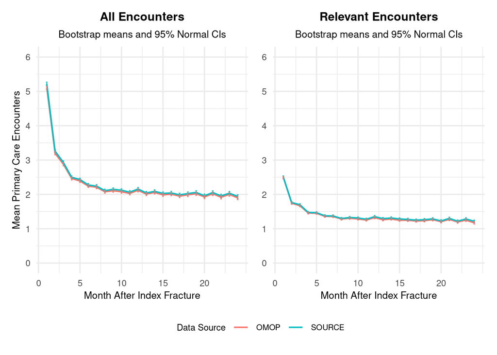

#### **Users only**

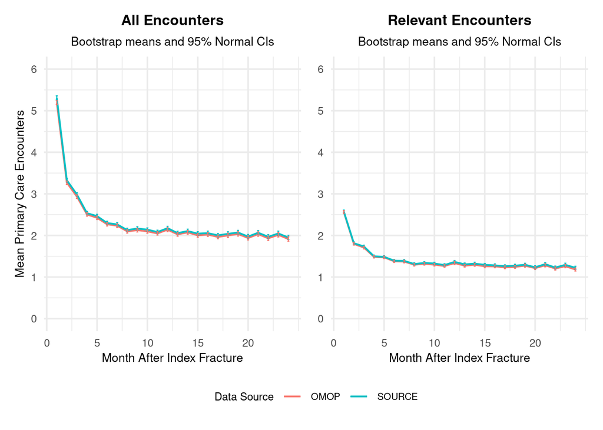

# Costs

### Overall

#### All Patients

##### All Encounters

###### **Observed**

| Cohort | mean | min | max | sd | median | lower_q | upper_q | se | ci_lower | ci_upper |
| --- | --- | --- | --- | --- | --- | --- | --- | --- | --- | --- |
| SOURCE | 757.69 | 0 | 12916.41 | 767.53 | 535.3 | 233.51 | 1025.09 | 5.05 | 747.79 | 767.59 |
| OMOP | 793.01 | 0 | 13132.31 | 792.59 | 563.61 | 248.25 | 1069.41 | 5.24 | 782.74 | 803.28 |

###### **Bootstrap** (with confidence intervals derived using normal, basic, and percentile methods).

| Cohort | mean | variance | sd | se | ci_norm_lower | ci_norm_upper | ci_basic_lower | ci_basic_upper | ci_perc_lower | ci_perc_upper |
| --- | --- | --- | --- | --- | --- | --- | --- | --- | --- | --- |
| SOURCE | 757.307 | 26.374 | 5.136 | 0.162 | 748.009 | 768.14 | 747.563 | 768.098 | 747.283 | 767.818 |
| OMOP | 792.951 | 28.132 | 5.304 | 0.168 | 782.672 | 803.464 | 782.343 | 803.472 | 782.547 | 803.677 |

##### Clinically Relevant Encounters

###### **Observed**

| Cohort | mean | min | max | sd | median | lower_q | upper_q | se | ci_lower | ci_upper |
| --- | --- | --- | --- | --- | --- | --- | --- | --- | --- | --- |
| SOURCE | 728.81 | 0 | 12424 | 747.33 | 514.52 | 222 | 989.01 | 4.92 | 719.17 | 738.44 |
| OMOP | 689.47 | 0 | 12421.25 | 719.4 | 481 | 201 | 932.01 | 4.75 | 680.15 | 698.79 |

###### **Bootstrap** (with confidence intervals derived using normal, basic, and percentile methods).

| Cohort | mean | variance | sd | se | ci_norm_lower | ci_norm_upper | ci_basic_lower | ci_basic_upper | ci_perc_lower | ci_perc_upper |
| --- | --- | --- | --- | --- | --- | --- | --- | --- | --- | --- |
| SOURCE | 728.736 | 22.465 | 4.74 | 0.15 | 719.586 | 738.165 | 719.466 | 738.154 | 719.457 | 738.145 |
| OMOP | 689.404 | 23.25 | 4.822 | 0.152 | 680.083 | 698.985 | 679.467 | 699.001 | 679.937 | 699.471 |

#### Users Only

##### All Encounters

###### **Observed**

| Cohort | mean | min | max | sd | median | lower_q | upper_q | se | ci_lower | ci_upper |
| --- | --- | --- | --- | --- | --- | --- | --- | --- | --- | --- |
| SOURCE | 779.08 | 1.9 | 12916.41 | 767.7 | 557.47 | 254.42 | 1044.88 | 5.12 | 769.04 | 789.12 |
| OMOP | 816.56 | 2.22 | 13132.31 | 792.95 | 586.75 | 272.47 | 1092.07 | 5.32 | 806.14 | 826.99 |

###### **Bootstrap** (with confidence intervals derived using normal, basic, and percentile methods).

| Cohort | mean | variance | sd | se | ci_norm_lower | ci_norm_upper | ci_basic_lower | ci_basic_upper | ci_perc_lower | ci_perc_upper |
| --- | --- | --- | --- | --- | --- | --- | --- | --- | --- | --- |
| SOURCE | 779.065 | 25.167 | 5.017 | 0.159 | 769.259 | 788.924 | 769.409 | 789.498 | 768.659 | 788.748 |
| OMOP | 816.479 | 27.79 | 5.272 | 0.167 | 806.318 | 826.982 | 806.378 | 826.793 | 806.337 | 826.752 |

##### Clinically Relevant Encounters

###### **Observed**

| Cohort | mean | min | max | sd | median | lower_q | upper_q | se | ci_lower | ci_upper |
| --- | --- | --- | --- | --- | --- | --- | --- | --- | --- | --- |
| SOURCE | 749.57 | 0.95 | 12424 | 747.57 | 530.16 | 236.98 | 1004 | 4.99 | 739.79 | 759.34 |
| OMOP | 710.63 | 0.95 | 12421.25 | 719.99 | 497.54 | 222 | 954.03 | 4.83 | 701.17 | 720.1 |

###### **Bootstrap** (with confidence intervals derived using normal, basic, and percentile methods).

| Cohort | mean | variance | sd | se | ci_norm_lower | ci_norm_upper | ci_basic_lower | ci_basic_upper | ci_perc_lower | ci_perc_upper |
| --- | --- | --- | --- | --- | --- | --- | --- | --- | --- | --- |
| SOURCE | 749.563 | 23.914 | 4.89 | 0.155 | 739.987 | 759.156 | 739.768 | 759.405 | 739.73 | 759.367 |
| OMOP | 710.54 | 22.702 | 4.765 | 0.151 | 701.387 | 720.065 | 701.287 | 719.786 | 701.48 | 719.98 |

### Yearly

We derived two types of mean estimates:

- Mean among *exposed patients* only: average number of visits among patients observed in each year with patients not observed in a given month excluded from the denominator (i.e., mean = (number of visits in the year) / (number of patients exposed that year)).
- Mean across *all patients* in the cohort: average number of visits per year using the full cohort as the denominator, regardless of whether patients were observed in that period. This approach assumes unobserved patients had zero visits, which may be conceptually misleading (e.g., for patients who died or were censored). However, it enables internal consistency checks: the sum of period-specific means aligns with the overall period mean because the denominator remains constant across years and is the same as the one used to derive the mean for the overall period.
- Both means are presented in the “observed” tables. Bootstrapping was conducted for the exposed-patient means only. Corresponding results for the full cohort means will be included in the appendix.
- The analysis was conducted including *partial years*, i.e., years in which patients were exposed for just part of the time

#### All Patients

##### All Encounters

###### **Observed**

| Cohort | year | mean_exposed | min | max | sd | q1 | median | q3 | n_exposed | total_costs | mean_all_patients | se | lower | upper |
| --- | --- | --- | --- | --- | --- | --- | --- | --- | --- | --- | --- | --- | --- | --- |
| SOURCE | 1 | 496.55 | 0 | 8450.17 | 465.23 | 185 | 373.28 | 665.21 | 23106 | 11473373.07 | 496.55 | 3.06 | 490.55 | 502.55 |
| SOURCE | 2 | 421.95 | 0 | 5759.32 | 438.48 | 118.64 | 303.46 | 579.88 | 14300 | 6033822.19 | 261.14 | 3.67 | 414.76 | 429.13 |
| OMOP | 1 | 521.33 | 0 | 8348.22 | 478.85 | 196.59 | 392.86 | 697.03 | 22900 | 11938415.66 | 521.33 | 3.16 | 515.13 | 527.53 |
| OMOP | 2 | 439 | 0 | 5911.47 | 452.76 | 124.1 | 315.43 | 603.56 | 14172 | 6221502.85 | 271.68 | 3.8 | 431.54 | 446.45 |

###### **Bootstrap** (with confidence intervals derived using normal, basic, and percentile methods).

| Cohort | year | mean | variance | sd | se | ci_lower_norm | ci_upper_norm | ci_lower_basic | ci_upper_basic | ci_lower_perc | ci_upper_perc |
| --- | --- | --- | --- | --- | --- | --- | --- | --- | --- | --- | --- |
| SOURCE | 1 | 496.508 | 8.795 | 2.966 | 0.094 | 490.787 | 502.412 | 490.353 | 502.436 | 490.672 | 502.754 |
| SOURCE | 2 | 421.98 | 12.914 | 3.594 | 0.114 | 414.868 | 428.954 | 415.122 | 428.916 | 414.975 | 428.769 |
| OMOP | 1 | 521.264 | 10.468 | 3.235 | 0.102 | 515.051 | 527.734 | 515.152 | 527.688 | 514.969 | 527.504 |
| OMOP | 2 | 438.946 | 14.533 | 3.812 | 0.121 | 431.581 | 446.525 | 431.778 | 446.596 | 431.403 | 446.221 |

##### Clinically Relevant Encounters

###### **Observed**

| Cohort | year | mean_exposed | min | max | sd | q1 | median | q3 | n_exposed | total_costs | mean_all_patients | se | lower | upper |
| --- | --- | --- | --- | --- | --- | --- | --- | --- | --- | --- | --- | --- | --- | --- |
| SOURCE | 1 | 476.31 | 0 | 8424.72 | 454.02 | 169.89 | 355.2 | 639.48 | 23106 | 11005605.22 | 476.31 | 2.99 | 470.45 | 482.16 |
| SOURCE | 2 | 407.98 | 0 | 5468 | 427.47 | 111 | 296 | 560.67 | 14300 | 5834177.48 | 252.5 | 3.57 | 400.98 | 414.99 |
| OMOP | 1 | 450.65 | 0 | 8322.77 | 437.66 | 151.3 | 333 | 606.57 | 22900 | 10319856.46 | 450.65 | 2.89 | 444.98 | 456.32 |
| OMOP | 2 | 385.9 | 0 | 5465.25 | 410.09 | 111 | 269 | 531.37 | 14172 | 5468987.9 | 238.82 | 3.44 | 379.15 | 392.65 |

###### **Bootstrap** (with confidence intervals derived using normal, basic, and percentile methods).

| Cohort | year | mean | variance | sd | se | ci_lower_norm | ci_upper_norm | ci_lower_basic | ci_upper_basic | ci_lower_perc | ci_upper_perc |
| --- | --- | --- | --- | --- | --- | --- | --- | --- | --- | --- | --- |
| SOURCE | 1 | 476.268 | 8.33 | 2.886 | 0.091 | 470.693 | 482.007 | 470.337 | 482.025 | 470.594 | 482.281 |
| SOURCE | 2 | 408.032 | 12.257 | 3.501 | 0.111 | 401.075 | 414.798 | 401.35 | 414.737 | 401.232 | 414.618 |
| OMOP | 1 | 450.59 | 8.78 | 2.963 | 0.094 | 444.9 | 456.516 | 444.736 | 456.46 | 444.837 | 456.562 |
| OMOP | 2 | 385.836 | 11.993 | 3.463 | 0.11 | 379.178 | 392.753 | 379.094 | 392.832 | 378.969 | 392.708 |

#### Users Only

##### All Encounters

###### **Observed**

| Cohort | year | mean_exposed | min | max | sd | q1 | median | q3 | n_exposed | total_costs | mean_all_patients | se | lower | upper |
| --- | --- | --- | --- | --- | --- | --- | --- | --- | --- | --- | --- | --- | --- | --- |
| SOURCE | 1 | 510.51 | 0 | 8450.17 | 464.3 | 196.81 | 384.35 | 677.01 | 22466 | 11469038.49 | 510.51 | 3.1 | 504.43 | 516.58 |
| SOURCE | 2 | 425.33 | 0 | 5759.32 | 438.61 | 121.37 | 305.84 | 582.39 | 14186 | 6033738.88 | 268.57 | 3.68 | 418.11 | 432.55 |
| OMOP | 1 | 536.56 | 0 | 8348.22 | 477.98 | 210.83 | 407 | 710.75 | 22218 | 11921330.54 | 536.56 | 3.21 | 530.28 | 542.85 |
| OMOP | 2 | 442.94 | 0 | 5911.47 | 452.89 | 127.73 | 318.88 | 606.52 | 14045 | 6221101.53 | 280 | 3.82 | 435.45 | 450.43 |

###### **Bootstrap**

| Cohort | year | mean | variance | sd | se | ci_lower_norm | ci_upper_norm | ci_lower_basic | ci_upper_basic | ci_lower_perc | ci_upper_perc |
| --- | --- | --- | --- | --- | --- | --- | --- | --- | --- | --- | --- |
| SOURCE | 1 | 510.553 | 9.113 | 3.019 | 0.095 | 504.543 | 516.376 | 504.486 | 516.403 | 504.61 | 516.527 |
| SOURCE | 2 | 425.128 | 13.558 | 3.682 | 0.116 | 418.316 | 432.75 | 418.285 | 432.725 | 417.936 | 432.376 |
| OMOP | 1 | 536.585 | 9.921 | 3.15 | 0.1 | 530.365 | 542.712 | 530.579 | 542.471 | 530.652 | 542.544 |
| OMOP | 2 | 442.721 | 14.846 | 3.853 | 0.122 | 435.608 | 450.712 | 435.362 | 450.63 | 435.252 | 450.519 |

##### Clinically Relevant Encounters

###### **Observed**

| Cohort | year | mean_exposed | min | max | sd | q1 | median | q3 | n_exposed | total_costs | mean_all_patients | se | lower | upper |
| --- | --- | --- | --- | --- | --- | --- | --- | --- | --- | --- | --- | --- | --- | --- |
| SOURCE | 1 | 489.88 | 0 | 8424.72 | 453.17 | 185 | 370 | 652.41 | 22466 | 11005605.22 | 489.88 | 3.02 | 483.95 | 495.8 |
| SOURCE | 2 | 411.26 | 0 | 5468 | 427.61 | 112.9 | 296 | 563.2 | 14186 | 5834177.48 | 259.69 | 3.59 | 404.23 | 418.3 |
| OMOP | 1 | 464.48 | 0 | 8322.77 | 437.03 | 172.55 | 343 | 619.45 | 22218 | 10319856.46 | 464.48 | 2.93 | 458.73 | 470.23 |
| OMOP | 2 | 389.39 | 0 | 5465.25 | 410.28 | 111 | 273.98 | 537.37 | 14045 | 5468987.9 | 246.15 | 3.46 | 382.6 | 396.18 |

###### **Bootstrap**

| Cohort | year | mean | variance | sd | se | ci_lower_norm | ci_upper_norm | ci_lower_basic | ci_upper_basic | ci_lower_perc | ci_upper_perc |
| --- | --- | --- | --- | --- | --- | --- | --- | --- | --- | --- | --- |
| SOURCE | 1 | 489.926 | 8.691 | 2.948 | 0.093 | 484.053 | 495.609 | 483.829 | 495.603 | 484.154 | 495.927 |
| SOURCE | 2 | 411.078 | 12.943 | 3.598 | 0.114 | 404.397 | 418.499 | 404.493 | 418.603 | 403.923 | 418.033 |
| OMOP | 1 | 464.477 | 8.329 | 2.886 | 0.091 | 458.831 | 470.144 | 459.045 | 470.102 | 458.861 | 469.918 |
| OMOP | 2 | 389.209 | 12.12 | 3.481 | 0.11 | 382.748 | 396.395 | 382.223 | 396.143 | 382.638 | 396.558 |

### Monthly

The analysis was conducted using two time-based definitions:

- *All months*: includes all calendar months in which the patient had any exposure, even if partial.
- *Full months*: includes only calendar months where the patient was fully exposed (e.g., excludes final partial month).

The results presented here are based on the “all-months” approach. Those from the the analysis restricted to full months will be included in the appendix.

Like for the yearly analysis, means were derived among *exposed patients* only: average number of visits among patients observed in each month with patients not observed in a given month excluded from the denominator (i.e., mean = (number of visits in the month) / (number of patients exposed that month)). Separately, means were also calculated across all patients in the cohort and used for internal validation (i.e., the sum of all monthly means equals the overall period). These results will be reported in the appendix.

#### **All Patients**

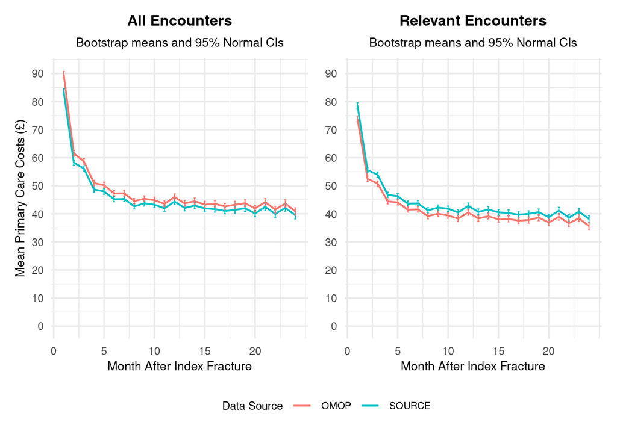

#### **Users only**

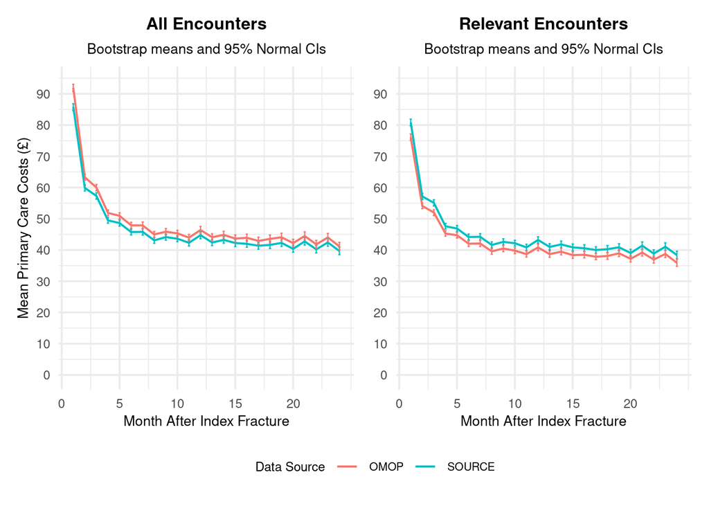

# Conclusions

### Healthcare Resource Use

• Primary care **resource use was slightly higher in the source data compared to OMOP, although the difference was not statistically significant**, as indicated by overlapping bootstrap confidence intervals (CIs).

• This pattern was consistent across the overall observation period, as well as in yearly and monthly analyses. It held true both for the full patient population and when analyses were restricted to users only.

### Costs

• Cost patterns diverged from those observed for resource use, with **OMOP showing higher visit costs than the source data, accompanied by non-overlapping CIs**. This was consistent across all patients, in overall, yearly, and monthly analyses, as well as for users only.

• However, when **restricting the analysis to clinically relevant encounters**, the pattern reversed: the **source data showed higher costs than OMOP, mirroring the trend seen in healthcare resource use**.

• This discrepancy can be attributed to the fact that **clinical relevance was defined independently** in OMOP and the source data and that **source uses a more granular specialty definition**.

• For example, multiple source specialties may map to a single OMOP specialty. In such cases, some of the original source specialties may be considered clinically relevant, even though the aggregated OMOP specialty is not. This issue is especially pronounced for **source specialties that lack a direct mapping to an OMOP concept** (uncategorised); these **were classified as not relevant in OMOP, even though some were considered clinically relevant in the source analysis**.

• The analysis was verified using the same unit cost codes across both datasets to confirm that observed differences were not attributable to coding inconsistencies.